# SLR and MLR

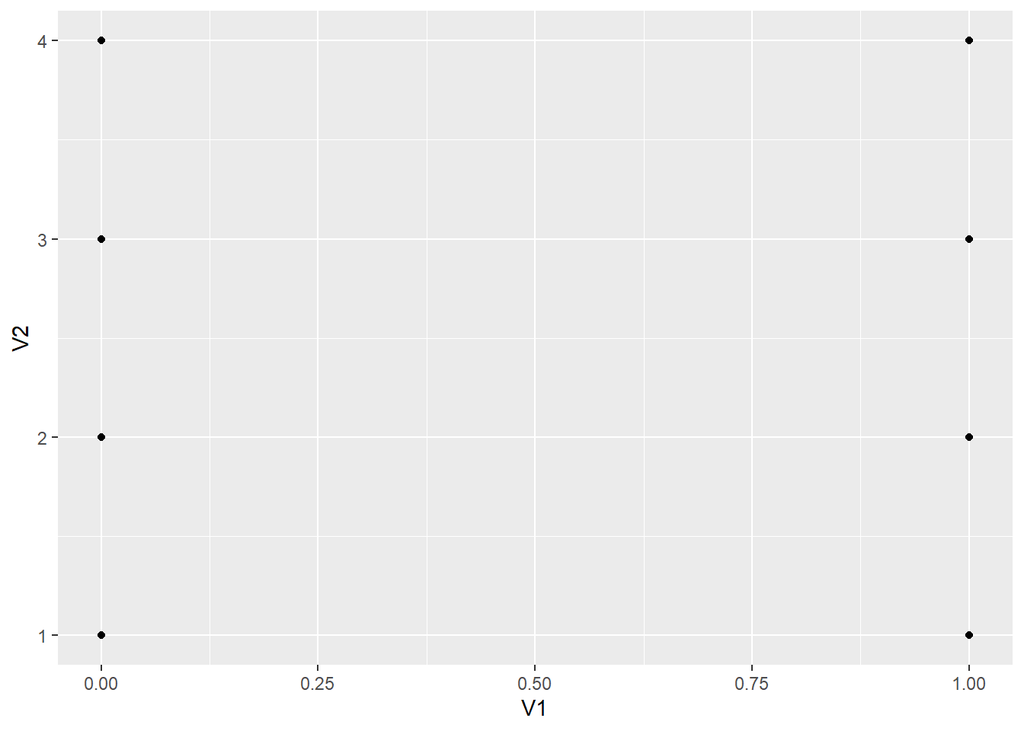

```r
#deg 3 model
df %>% ggplot(aes(x = V1, y = V2)) + geom_point()
```

```r
df_3 = df %>% mutate(V_2 = V2^2, V_22 = V2^3)
#View(df_3)
fit = lm(V1~V2+V_2+V_22, df_3)
summary(fit)
```

```
##
## Call:
## lm(formula = V1 ~ V2 + V_2 + V_22, data = df_3)
##
## Residuals:
##     Min      1Q  Median      3Q     Max
## -0.9136  0.1303  0.1303  0.1303  0.4681
##
## Coefficients:
##             Estimate Std. Error t value Pr(>|t|)
## (Intercept) -0.14943    0.26456  -0.565  0.57234
## V2           0.94905    0.34702   2.735  0.00637 **
## V_2         -0.30000    0.14115  -2.125  0.03383 *
## V_22         0.03229    0.01803   1.791  0.07364 .
## ---
## Signif. codes:  0 '***' 0.001 '**' 0.01 '*' 0.05 '.' 0.1 ' ' 1
##
## Residual standard error: 0.3594 on 866 degrees of freedom
## Multiple R-squared:  0.04766,    Adjusted R-squared:  0.04436
## F-statistic: 14.45 on 3 and 866 DF,  p-value: 3.441e-09
```

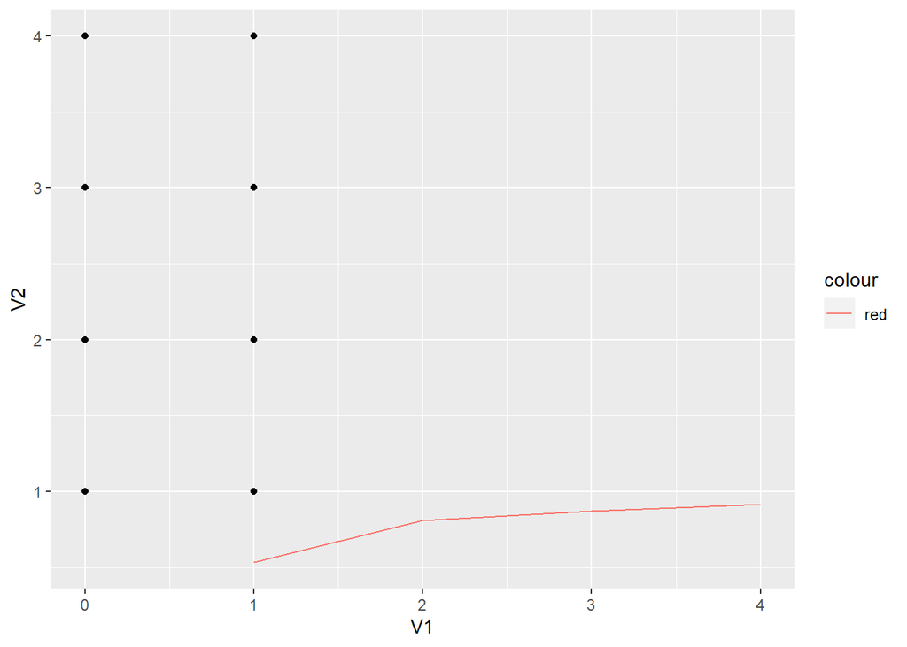

```r
preds = predict(fit)
df_3 %>% ggplot(aes(x = V1, y = V2)) + geom_point() +geom_line(data = df_3, aes( x = V2, y = preds, col = "red"))
```

Call: lm(formula = V1 ~ V2, data = df)

Residuals: Min 1Q Median 3Q Max -0.9644 0.1337 0.1337 0.1337 0.3300

Coefficients: Estimate Std. Error t value Pr(>|t|)  
(Intercept) 0.57188 0.04899 11.673 < 2e-16 *V2 0.09813 0.01742 5.633 2.39e-08* — Signif. codes: 0 ‘**’ 0.001 ‘**’ 0.01 ‘’ 0.05 ‘.’ 0.1 ‘ ’ 1

Residual standard error: 0.3613 on 868 degrees of freedom Multiple R-squared: 0.03527, Adjusted R-squared: 0.03415 F-statistic: 31.73 on 1 and 868 DF, p-value: 2.393e-08

Degree model 2 appears to have some traction:

Call: lm(formula = V1 ~ V2 + V_2, data = df2)

Residuals: Min 1Q Median 3Q Max -0.8872 0.1179 0.1179 0.1179 0.4226

Coefficients: Estimate Std. Error t value Pr(>|t|)  
(Intercept) 0.27775 0.11462 2.423 0.015589 *  
V2 0.34877 0.09007 3.872 0.000116 * **V_2 -0.04910 0.01731 -2.836 0.004676** — Signif. codes: 0 ‘**’ 0.001 ‘**’ 0.01 ‘’ 0.05 ‘.’ 0.1 ‘ ’ 1

Residual standard error: 0.3599 on 867 degrees of freedom Multiple R-squared: 0.04413, Adjusted R-squared: 0.04193 F-statistic: 20.02 on 2 and 867 DF, p-value: 3.179e-09

Let’s try model 3 v2^3:

Call: lm(formula = V1 ~ V2 + V_2 + V_22, data = df_3)

Residuals: Min 1Q Median 3Q Max -0.9136 0.1303 0.1303 0.1303 0.4681

Coefficients: Estimate Std. Error t value Pr(>|t|)  
(Intercept) -0.14943 0.26456 -0.565 0.57234  
V2 0.94905 0.34702 2.735 0.00637 ** V_2 -0.30000 0.14115 -2.125 0.03383 * V_22 0.03229 0.01803 1.791 0.07364 . — Signif. codes: 0 ‘**’ 0.001 ‘**’ 0.01 ‘’ 0.05 ‘.’ 0.1 ‘ ’ 1

Residual standard error: 0.3594 on 866 degrees of freedom Multiple R-squared: 0.04766, Adjusted R-squared: 0.04436 F-statistic: 14.45 on 3 and 866 DF, p-value: 3.441e-09

It doesn’t appear that V2^3 is a viable resource as the p-value is greater than .05..but, not by much. What’s interesting is what it’s done to the y intercept and to the V2 coefficient.

## Okay, one more variable to run through this process:

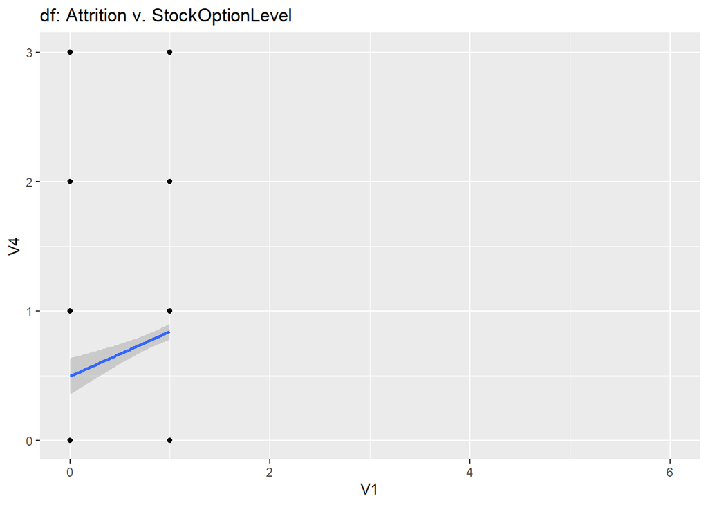

```r
#Recall

df <- as.data.frame(cbind(KNN_2$Attrition, KNN_2$JobInvolvement, KNN_2$OverTime, KNN_2$StockOptionLevel))
#View(df)
df %>% ggplot(aes(x = V1, y = V4)) + geom_point() + ggtitle("df: Attrition v. StockOptionLevel") + geom_smooth(method = "lm") + xlim(0,6)
```

```r
# degree 1 model
fit = lm(V1~V4, data = df)
summary(fit)
```

```
##
## Call:
## lm(formula = V1 ~ V4, data = df)
##
## Residuals:
##      Min       1Q   Median       3Q      Max
## -0.98031  0.08342  0.14715  0.21088  0.21088
##
## Coefficients:
##             Estimate Std. Error t value Pr(>|t|)
## (Intercept)  0.78912    0.01671   47.22  < 2e-16 ***
## V4           0.06373    0.01439    4.43 1.06e-05 ***
## ---
## Signif. codes:  0 '***' 0.001 '**' 0.01 '*' 0.05 '.' 0.1 ' ' 1
##
## Residual standard error: 0.3638 on 868 degrees of freedom
## Multiple R-squared:  0.02211,    Adjusted R-squared:  0.02098
## F-statistic: 19.62 on 1 and 868 DF,  p-value: 1.065e-05
```

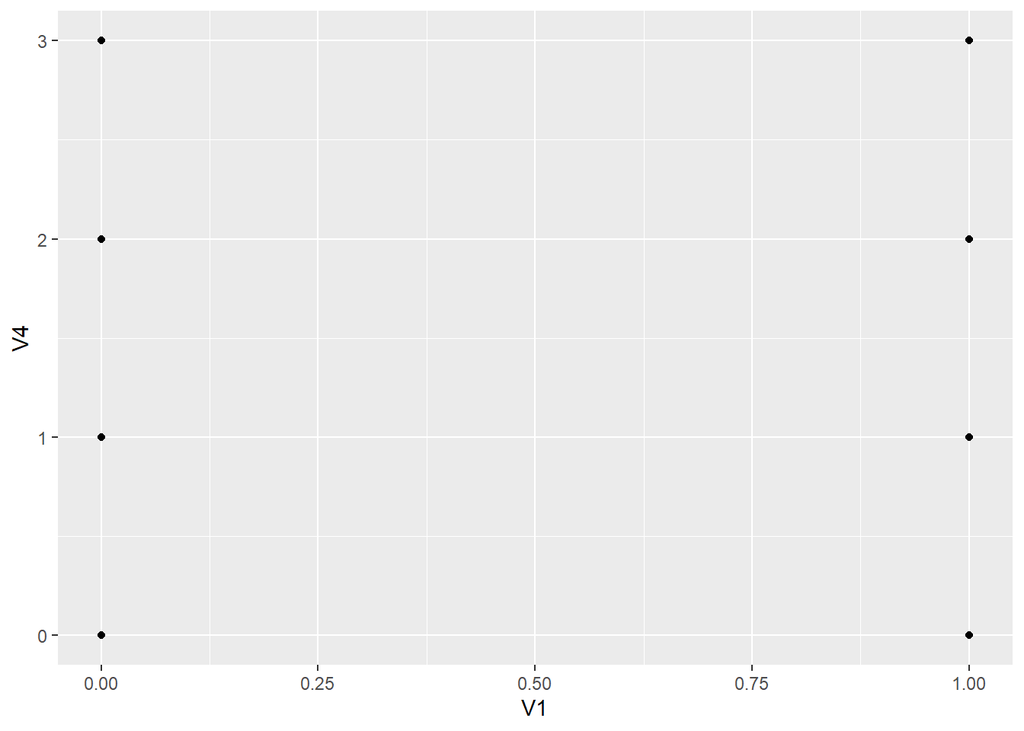

```r
#degree 2 model
df %>% ggplot(aes(x = V1, y = V4)) + geom_point()
```

```r
df_4 = df %>% mutate(V_4 = V4^2) #df_4 is distinct from df4 so we don't get any interaction.  And, consistent with the prior analysis.
fit = lm(V1~V4+V_4, df_4)
summary(fit)
```

```
##
## Call:
## lm(formula = V1 ~ V4 + V_4, data = df_4)
##
## Residuals:
##      Min       1Q   Median       3Q      Max
## -0.94491  0.05930  0.07194  0.25986  0.25986
##
## Coefficients:
##             Estimate Std. Error t value Pr(>|t|)
## (Intercept)  0.74014    0.01814  40.812  < 2e-16 ***
## V4           0.27346    0.03637   7.520 1.37e-13 ***
## V_4         -0.08554    0.01367  -6.255 6.23e-10 ***
## ---
## Signif. codes:  0 '***' 0.001 '**' 0.01 '*' 0.05 '.' 0.1 ' ' 1
##
## Residual standard error: 0.3561 on 867 degrees of freedom
## Multiple R-squared:  0.06433,    Adjusted R-squared:  0.06217
## F-statistic: 29.81 on 2 and 867 DF,  p-value: 3.03e-13
```

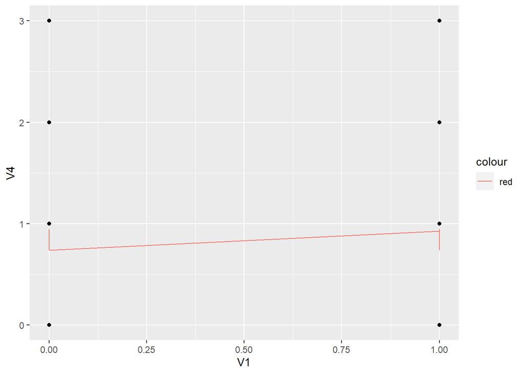

```r
preds = predict(fit)
df_4 %>% ggplot(aes(x = V1, y = V4)) + geom_point() +geom_line(data = df_4, aes( x = V1, y = preds, col = "red"))
```

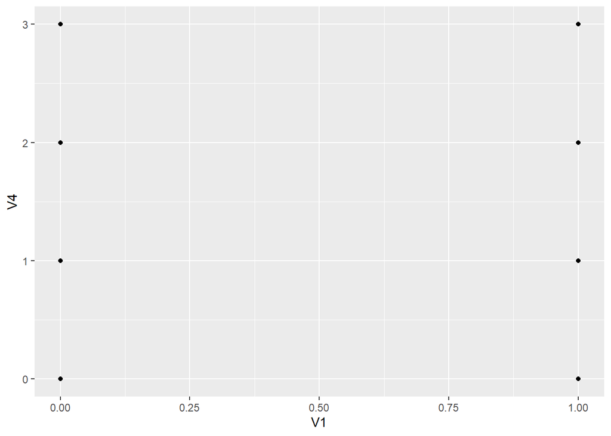

```r
#deg 3 model
df %>% ggplot(aes(x = V1, y = V4)) + geom_point()
```

```r
df_4 = df %>% mutate(V_4 = V4^2, V_44 = V4^3)
#View(df_4)
fit = lm(V1~V4+V_4+V_44, df_4)
summary(fit)
```

```
##
## Call:
## lm(formula = V1 ~ V4 + V_4 + V_44, data = df_4)
##
## Residuals:
##      Min       1Q   Median       3Q      Max
## -0.96296  0.04679  0.07606  0.25858  0.25858
##
## Coefficients:
##             Estimate Std. Error t value Pr(>|t|)
## (Intercept)  0.74142    0.01830  40.522   <2e-16 ***
## V4           0.22871    0.09013   2.538   0.0113 *
## V_4         -0.03342    0.09701  -0.344   0.7306
## V_44        -0.01278    0.02354  -0.543   0.5875
## ---
## Signif. codes:  0 '***' 0.001 '**' 0.01 '*' 0.05 '.' 0.1 ' ' 1
##
## Residual standard error: 0.3562 on 866 degrees of freedom
## Multiple R-squared:  0.06465,    Adjusted R-squared:  0.06141
## F-statistic: 19.95 on 3 and 866 DF,  p-value: 1.642e-12
```

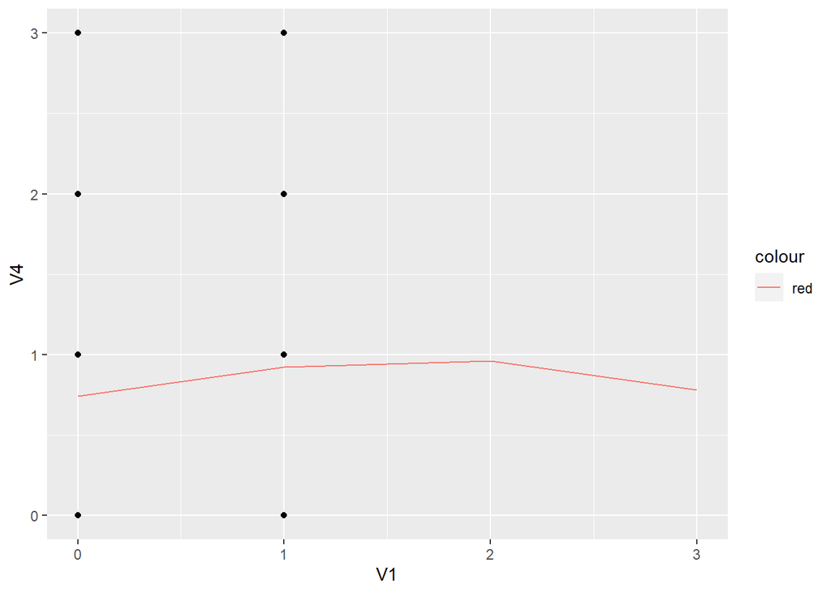

```r
preds = predict(fit)
df_4 %>% ggplot(aes(x = V1, y = V4)) + geom_point() +geom_line(data = df_4, aes( x = V4, y = preds, col = "red"))
```

### Single variable model 1:

Call: lm(formula = V1 ~ V4, data = df)

Residuals: Min 1Q Median 3Q Max -0.98031 0.08342 0.14715 0.21088 0.21088

Coefficients: Estimate Std. Error t value Pr(>|t|)  
(Intercept) 0.78912 0.01671 47.22 < 2e-16 *V4 0.06373 0.01439 4.43 1.06e-05* — Signif. codes: 0 ‘**’ 0.001 ‘**’ 0.01 ‘’ 0.05 ‘.’ 0.1 ‘ ’ 1

Residual standard error: 0.3638 on 868 degrees of freedom Multiple R-squared: 0.02211, Adjusted R-squared: 0.02098 F-statistic: 19.62 on 1 and 868 DF, p-value: 1.065e-05

###Model 2:

Call: lm(formula = V1 ~ V4 + V_4, data = df_4)

Residuals: Min 1Q Median 3Q Max -0.94491 0.05930 0.07194 0.25986 0.25986

Coefficients: Estimate Std. Error t value Pr(>|t|)  
(Intercept) 0.74014 0.01814 40.812 < 2e-16 *V4 0.27346 0.03637 7.520 1.37e-13* V_4 -0.08554 0.01367 -6.255 6.23e-10 *** — Signif. codes: 0 ‘**’ 0.001 ‘**’ 0.01 ‘’ 0.05 ‘.’ 0.1 ‘ ’ 1

Residual standard error: 0.3561 on 867 degrees of freedom Multiple R-squared: 0.06433, Adjusted R-squared: 0.06217 F-statistic: 29.81 on 2 and 867 DF, p-value: 3.03e-13

### Model 3:

Call: lm(formula = V1 ~ V4 + V_4 + V_44, data = df_4)

Residuals: Min 1Q Median 3Q Max -0.96296 0.04679 0.07606 0.25858 0.25858

Coefficients: Estimate Std. Error t value Pr(>|t|)  
(Intercept) 0.74142 0.01830 40.522 <2e-16 ** *V4 0.22871 0.09013 2.538 0.0113*  
V_4 -0.03342 0.09701 -0.344 0.7306  
V_44 -0.01278 0.02354 -0.543 0.5875  
— Signif. codes: 0 ‘**’ 0.001 ‘**’ 0.01 ‘’ 0.05 ‘.’ 0.1 ‘ ’ 1

Residual standard error: 0.3562 on 866 degrees of freedom Multiple R-squared: 0.06465, Adjusted R-squared: 0.06141 F-statistic: 19.95 on 3 and 866 DF, p-value: 1.642e-12

The V4^2 model has some legs, but it breaks down with a cubed model, completely.

What does that leave us with?

V1 = V2 +V2^2 - V3 + V4 -V4^2

How do we evaluate the validity of that entire model?

fit = lm(V1~V2 +V_2 -V3 + V4 + V_4 - V_44, df_?) The data.frame must be created to include all of the components.  
df_Final <- as.data.frame(cbind(df, df_2, df_3, df_4) (these data.frame’s are not properly named, but you get the idea.

```r
df_Final <- as.data.frame(cbind(df, df2, df_2, df3, df_4))
#df_Final


fit_Final = lm(formula = V1~V2 + V_2 - V3 + V4 - V_4, data = df_Final)
summary(fit_Final)
```

```
##
## Call:
## lm(formula = V1 ~ V2 + V_2 - V3 + V4 - V_4, data = df_Final)
##
## Residuals:
##      Min       1Q   Median       3Q      Max
## -1.01131  0.04748  0.10628  0.16507  0.46163
##
## Coefficients:
##             Estimate Std. Error t value Pr(>|t|)
## (Intercept)  0.23977    0.11393   2.105  0.03561 *
## V2           0.34870    0.08923   3.908  0.00010 ***
## V_2         -0.05011    0.01716  -2.921  0.00358 **
## V4           0.05879    0.01414   4.158 3.53e-05 ***
## ---
## Signif. codes:  0 '***' 0.001 '**' 0.01 '*' 0.05 '.' 0.1 ' ' 1
##
## Residual standard error: 0.3565 on 866 degrees of freedom
## Multiple R-squared:  0.06285,    Adjusted R-squared:  0.0596
## F-statistic: 19.36 on 3 and 866 DF,  p-value: 3.731e-12
```

This would appear to be the final multiple linear regression equation results:

Call: lm(formula = V1 ~ V2 + V_2 - V3 + V4 - V_4, data = df_Final)

Residuals: Min 1Q Median 3Q Max -1.01131 0.04748 0.10628 0.16507 0.46163

Coefficients: Estimate Std. Error t value Pr(>|t|)  
(Intercept) 0.23977 0.11393 2.105 0.03561 *  
V2 0.34870 0.08923 3.908 0.00010 **V_2 -0.05011 0.01716 -2.921 0.00358** V4 0.05879 0.01414 4.158 3.53e-05 ** — Signif. codes: 0 ‘**’ 0.001 ‘**’ 0.01 ‘’ 0.05 ‘.’ 0.1 ‘ ’ 1

Residual standard error: 0.3565 on 866 degrees of freedom Multiple R-squared: 0.06285, Adjusted R-squared: 0.0596 F-statistic: 19.36 on 3 and 866 DF, p-value: 3.731e-12

This is the equation I’ll work on getting into a ShinyApp with sliders? Or, some sort of toggle for the values of each of the Coefficients. Interestingly enough, V3 (dropped out completely) as did V4^2. That worries me a bit. I’ve gone through my numbers, variables, data.frames and it appears that I’m going this correctly. Albeit a bit messy, but I’m sure I’ve got all the right variables and data.frames in there. Woo Hoo!!!

```r
#V3
```

## V1 = 0.23977 + .34870(V2) - 0.05011(V2^2) + 0.05879(V4)

V1 = Attrition V2 = JobInvolvement, V4 = StockOptionLevel

This makes sense logically.

From Here, there project moved to Project_2a.Rmd (sorry for the multiple files, but each file was becoming quite large and unwieldy.